# Report

##### regression decision trees & tree ensemble methods: bagging and random forests.

Now we have the five important predictors which are related to the response. Furthermore, we will expand on our linear regression model by adding non-linearity. Specifically, in this part, tree based methods will be applied which are non-linear and non-parametric methods. For this purpose, the *tree* library in *r* is used. Given that the *tree* function is sensitive on the names of the columns, they are changed to contain no spaces. If this was not done, an error would be recieved when calling the *tree* function.

```r
red <- red %>%
  rename ( fixed = `fixed acidity`,
           volatile = `volatile acidity`,
           citric = `citric acid`,
           sugar = `residual sugar`,
           free = `free sulfur dioxide`,
           total = `total sulfur dioxide`,


  )
```

Further on, we create a train data set consisting of 80% of the observations ^ [normally in cross validation the data set is divided into 80-20 or 75-25 for train and test data sets]. As seen, when fitted the tree, the *Residual mean deviance* will be 0.4111. Compared to the *training mean squared of errors* for the multiple linear regression model (0.4664348), this shows that at least the the model is performing better on the trained data set. However, the test MSE is important to us.

```r
library (tree)
set.seed(11)
train <- sample(1:nrow(red), 4 * nrow(red) / 5)
tree.red <- tree(formula = red$quality ~ ., data = red, subset = train)
summary(tree.red)
##
## Regression tree:
## tree(formula = red$quality ~ ., data = red, subset = train)
## Variables actually used in tree construction:
## [1] "alcohol"   "volatile"  "sulphates" "chlorides" "density"   "total"
## Number of terminal nodes:  11
## Residual mean deviance:  0.4111 = 520.4 / 1266
## Distribution of residuals:
##     Min.  1st Qu.   Median     Mean  3rd Qu.     Max.
## -2.51300 -0.51310 -0.09122  0.00000  0.48690  1.90900
```

The tree is plotted in the following. It is seen that the most decisive predictor is *alcohol*. This is different from the result obtained from multiple linear regression. Specifically, in the later approach combined with best subset selection *alcohol* was only chosen as the eighth variable for the model.

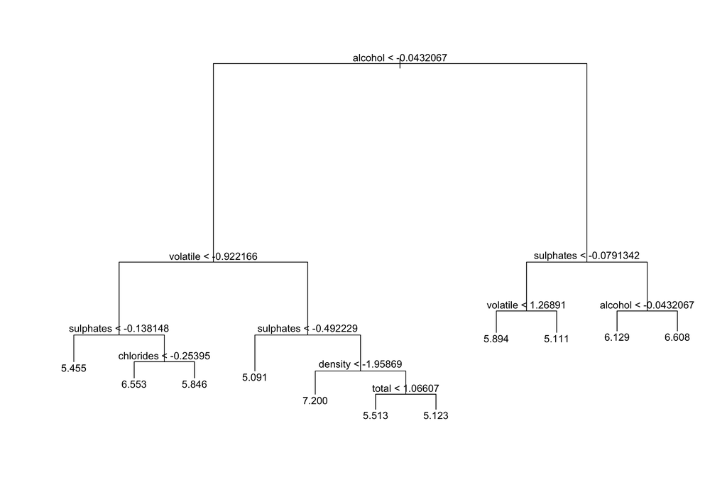

```r
plot (tree.red)
text(tree.red, pretty = 0)
```

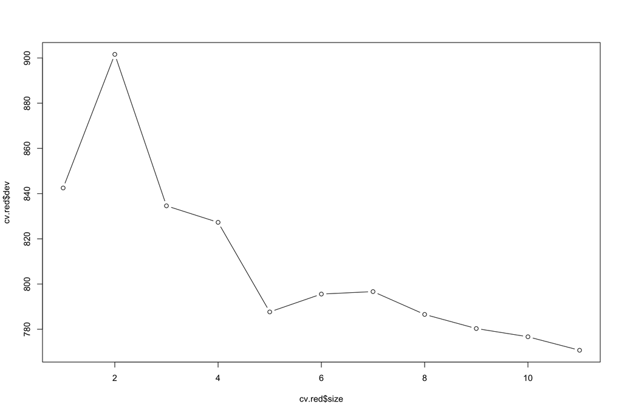

```r
cv.red <- cv.tree(tree.red)
plot(cv.red$size, cv.red$dev, type = "b")
```

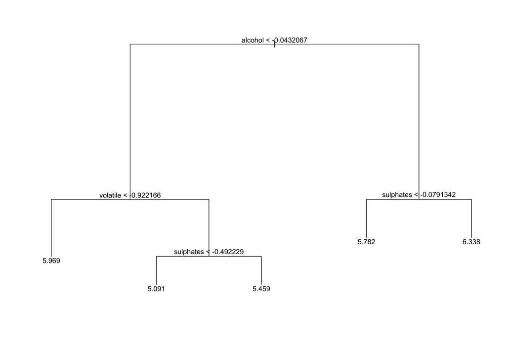

```r
prune.red <- prune.tree(tree.red, best = 5)
plot(prune.red)
text(prune.red, pretty = 0)
```

Particularly, in this pruned tree, the predictors *volatile acidity*, *sulphates*, and *alcohol* are used for classification. As seen below, 0.5878 is the *test MSE* for the tree. Even though the training MSE for the tree was lower compared to linear regression, the *test MSE* is very high. This shows that the tree-based approach has over fit the data.

```r
yhat <- predict(tree.red, newdata = red[-train, ])
red.test <- red[-train,]
mean((yhat - red.test$quality)^2, na.rm = TRUE)
## [1] 0.5878912
```

Moving on, we use ensemble approaches to combine single trees in order to get a better machine learning algorithm. The first ensemble approach is *bagging*.

```r
library (randomForest)
set.seed(11)
rf.red <- randomForest(quality ~ ., data = red,
subset = train, mtry = 11, importance = TRUE)
yhat.rf <- predict(rf.red, newdata = red[-train, ])
mean((yhat.rf - red.test$quality)^2)
## [1] 0.3492814
```

As seen the *test MSE* has dramatically decreased compared to using only a single tree and also using a multiple linear regression method. In below, *random forests* have been used which is the same as above, instead in *bagging* all predictors (11) will be used whereas in random forest roughly 1/3 of the predictors (4) will be used.

```r
library (randomForest)
set.seed(11)
rf.red <- randomForest(quality ~ ., data = red,
subset = train, mtry = 4, importance = TRUE)
yhat.rf <- predict(rf.red, newdata = red[-train, ])
mean((yhat.rf - red.test$quality)^2)
## [1] 0.3431366
```

Again we see a slight decrease in the test MSE compared to bagging. Overall, the following regression machine learning approaches have been applied: 1) multiple linear regression 2) best subset linear regression 3) decision tree 4) bagging 5) random forest. *Best subset linear regression* is the best for inference, but random forest has the lowest *test MSE* and thus, is better for prediction. Addmitedly, given that it is non-linear and non-parametric it is not very useful for inference.

##### logistic regression

In this section, we will apply logistic regression for the classification of the *quality* variable. As mentioned, this variable holds integer values, but the values can be treated as classes as well. Specifically, for the *red* data set there can be six classes as there are only six distinctive values for quality.

```r
red %>%
  distinct (quality)
##   quality
## 1       5
## 2       6
## 3       7
## 4       4
## 5       8
## 6       3
```

First step, by changing the *class* of the *quality* variable, we will convert it to a *qualitative* variable.

```r
red <- red %>%
  mutate (quality = as.factor(quality))
```

```r
library (caret)
library (nnet)
set.seed(11)

acc <- rep (0,10)
for (i in 1:10){
  training.samples <- red$quality %>%
  createDataPartition(p = 0.8, list = FALSE)
  train.data  <- red[training.samples, ]
  test.data <- red[-training.samples, ]
  # Fit the model
  model <- multinom(quality ~., data = train.data)
  # Make predictions
  predicted.classes <- model %>% predict(train.data)
  # Model accuracy
  acc[i] <- mean(predicted.classes == train.data$quality)
}
## # weights:  78 (60 variable)
## initial  value 2295.243880
## iter  10 value 1541.167221
## iter  20 value 1300.781757
## iter  30 value 1265.767375
## iter  40 value 1248.698125
## iter  50 value 1245.362916
## iter  60 value 1244.893794
## final  value 1244.878385
## converged
## # weights:  78 (60 variable)
## initial  value 2295.243880
## iter  10 value 1478.917405
## iter  20 value 1277.774918
## iter  30 value 1250.359941
## iter  40 value 1237.390020
## iter  50 value 1234.792265
## iter  60 value 1234.108504
## iter  70 value 1234.031132
## final  value 1234.031108
## converged
## # weights:  78 (60 variable)
## initial  value 2295.243880
## iter  10 value 1391.730954
## iter  20 value 1268.144850
## iter  30 value 1242.409489
## iter  40 value 1228.034757
## iter  50 value 1225.259420
## iter  60 value 1225.227440
## final  value 1225.227139
## converged
## # weights:  78 (60 variable)
## initial  value 2295.243880
## iter  10 value 1485.522197
## iter  20 value 1279.111119
## iter  30 value 1239.351657
## iter  40 value 1229.232005
## iter  50 value 1226.214304
## iter  60 value 1226.051331
## final  value 1226.041690
## converged
## # weights:  78 (60 variable)
## initial  value 2295.243880
## iter  10 value 1424.951418
## iter  20 value 1282.915620
## iter  30 value 1241.022426
## iter  40 value 1224.370063
## iter  50 value 1221.829451
## iter  60 value 1221.739267
## final  value 1221.737283
## converged
## # weights:  78 (60 variable)
## initial  value 2295.243880
## iter  10 value 1493.259024
## iter  20 value 1281.912627
## iter  30 value 1251.067624
## iter  40 value 1238.145260
## iter  50 value 1234.105351
## iter  60 value 1233.835401
## final  value 1233.827141
## converged
## # weights:  78 (60 variable)
## initial  value 2295.243880
## iter  10 value 1488.787541
## iter  20 value 1310.647529
## iter  30 value 1259.368693
## iter  40 value 1241.779376
## iter  50 value 1238.630109
## iter  60 value 1238.148909
## final  value 1238.148635
## converged
## # weights:  78 (60 variable)
## initial  value 2295.243880
## iter  10 value 1453.729647
## iter  20 value 1298.859292
## iter  30 value 1266.165484
## iter  40 value 1247.935341
## iter  50 value 1244.827909
## iter  60 value 1244.575660
## final  value 1244.574754
## converged
## # weights:  78 (60 variable)
## initial  value 2295.243880
## iter  10 value 1444.918965
## iter  20 value 1295.350517
## iter  30 value 1257.556063
## iter  40 value 1242.761546
## iter  50 value 1239.097454
## iter  60 value 1238.729613
## final  value 1238.718916
## converged
## # weights:  78 (60 variable)
## initial  value 2295.243880
## iter  10 value 1418.227503
## iter  20 value 1291.545955
## iter  30 value 1260.669652
## iter  40 value 1247.897431
## iter  50 value 1244.178754
## iter  60 value 1243.357150
## final  value 1243.332682
## converged
mean (acc)
## [1] 0.5696331
```

However, the question rises that does the model have a high prediction accuracy or is it predicting correctly by chance. This question especially becomes important when looking at the number of observations at each class in the bar charts at the beginning of the report. As seen, they are not equally divided and thus a model only predicting 5 and 6 will also have a good predictive accuracy for the red wine data set.

The below confusion matrix has been drawn. As seen many observations in the test data set have been mis-classified. Specifically, no observation in class 4 or 8 has been classified correctly. There are lots of errors in classes 5 6 and 7 as well.

```r
confusionMatrix(predict (model, test.data), test.data$quality,
                mode = "everything",
                positive="1")
## Confusion Matrix and Statistics
##
##           Reference
## Prediction  3  4  5  6  7  8
##          3  1  0  0  0  0  0
##          4  0  0  1  0  0  0
##          5  1  5 80 35  2  0
##          6  0  5 53 84 30  0
##          7  0  0  1  8  7  3
##          8  0  0  0  0  0  0
##
## Overall Statistics
##
##                Accuracy : 0.5443
##                  95% CI : (0.4876, 0.6002)
##     No Information Rate : 0.4272
##     P-Value [Acc > NIR] : 1.861e-05
##
##                   Kappa : 0.2498
##
##  Mcnemar's Test P-Value : NA
##
## Statistics by Class:
##
##                      Class: 3 Class: 4 Class: 5 Class: 6 Class: 7 Class: 8
## Sensitivity          0.500000 0.000000   0.5926   0.6614  0.17949 0.000000
## Specificity          1.000000 0.996732   0.7624   0.5344  0.95668 1.000000
## Pos Pred Value       1.000000 0.000000   0.6504   0.4884  0.36842      NaN
## Neg Pred Value       0.996825 0.968254   0.7150   0.7014  0.89226 0.990506
## Precision            1.000000 0.000000   0.6504   0.4884  0.36842       NA
## Recall               0.500000 0.000000   0.5926   0.6614  0.17949 0.000000
## F1                   0.666667      NaN   0.6202   0.5619  0.24138       NA
## Prevalence           0.006329 0.031646   0.4272   0.4019  0.12342 0.009494
## Detection Rate       0.003165 0.000000   0.2532   0.2658  0.02215 0.000000
## Detection Prevalence 0.003165 0.003165   0.3892   0.5443  0.06013 0.000000
## Balanced Accuracy    0.750000 0.498366   0.6775   0.5979  0.56808 0.500000
```

```r
library (caret)
library (nnet)
set.seed(11)

acc <- rep (0,10)
for (i in 1:10){
  training.samples <- red$quality %>%
  createDataPartition(p = 0.8, list = FALSE)
  train.data  <- red[training.samples, ]
  test.data <- red[-training.samples, ]
  # Fit the model
  model <- multinom(quality ~ volatile + chlorides + total + density + sulphates, data = train.data)
  # Make predictions
  predicted.classes <- model %>% predict(train.data)
  # Model accuracy
  acc[i] <- mean(predicted.classes == train.data$quality)
}
## # weights:  42 (30 variable)
## initial  value 2295.243880
## iter  10 value 1509.602348
## iter  20 value 1343.455691
## iter  30 value 1306.312932
## iter  40 value 1303.802889
## final  value 1303.802254
## converged
## # weights:  42 (30 variable)
## initial  value 2295.243880
## iter  10 value 1438.175171
## iter  20 value 1328.817706
## iter  30 value 1281.915946
## iter  40 value 1280.739260
## final  value 1280.736840
## converged
## # weights:  42 (30 variable)
## initial  value 2295.243880
## iter  10 value 1450.689586
## iter  20 value 1326.341893
## iter  30 value 1304.610302
## iter  40 value 1303.302851
## iter  40 value 1303.302842
## iter  40 value 1303.302842
## final  value 1303.302842
## converged
## # weights:  42 (30 variable)
## initial  value 2295.243880
## iter  10 value 1475.840661
## iter  20 value 1314.928391
## iter  30 value 1285.598188
## final  value 1285.014852
## converged
## # weights:  42 (30 variable)
## initial  value 2295.243880
## iter  10 value 1452.895419
## iter  20 value 1324.330281
## iter  30 value 1298.037947
## iter  40 value 1297.254899
## final  value 1297.254622
## converged
## # weights:  42 (30 variable)
## initial  value 2295.243880
## iter  10 value 1457.079971
## iter  20 value 1316.532661
## iter  30 value 1297.217493
## iter  40 value 1296.019064
## final  value 1296.019048
## converged
## # weights:  42 (30 variable)
## initial  value 2295.243880
## iter  10 value 1437.817066
## iter  20 value 1314.826605
## iter  30 value 1284.516567
## iter  40 value 1282.488617
## final  value 1282.488450
## converged
## # weights:  42 (30 variable)
## initial  value 2295.243880
## iter  10 value 1486.085361
## iter  20 value 1310.859046
## iter  30 value 1287.984553
## iter  40 value 1286.326721
## final  value 1286.326121
## converged
## # weights:  42 (30 variable)
## initial  value 2295.243880
## iter  10 value 1433.548280
## iter  20 value 1327.991231
## iter  30 value 1293.745672
## iter  40 value 1292.608660
## final  value 1292.608567
## converged
## # weights:  42 (30 variable)
## initial  value 2295.243880
## iter  10 value 1431.591848
## iter  20 value 1312.061208
## iter  30 value 1287.964951
## iter  40 value 1286.525954
## final  value 1286.521757
## converged
mean (acc)
## [1] 0.5508977
```

##### classification decision trees & tree ensemble methods: bagging and random forests.

The first naive approach where all predictors are used is like the following. Just like regression decision trees, *alcohol* is the *root* variable.

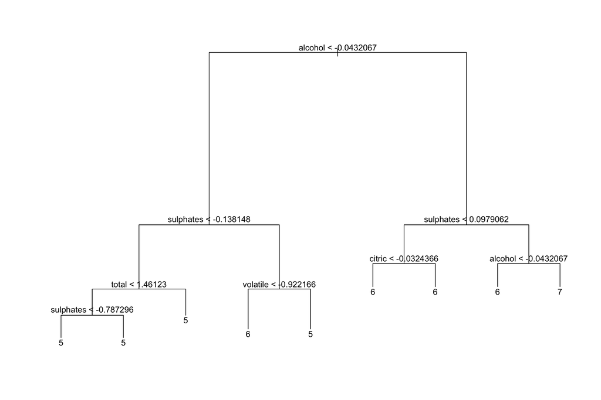

```r
tree.red2 <- tree(quality ~ . , red)
plot (tree.red2)
text (tree.red2, pretty = 0)
```

```r
set.seed(11)
train <- sample(1:nrow(red), 4 *nrow(red) / 5)
red.test <- red[-train, ]
tree.red <- tree(quality ~ ., red,
subset = train)
tree.pred <- predict(tree.red, red.test,
type = "class")
confusionMatrix(tree.pred, red.test$quality,
                mode = "everything",
                positive="1")
## Confusion Matrix and Statistics
##
##           Reference
## Prediction  3  4  5  6  7  8
##          3  0  0  0  0  0  0
##          4  0  0  0  0  0  0
##          5  2  7 82 66  9  1
##          6  0  3 49 73 23  5
##          7  0  0  0  0  0  0
##          8  0  0  0  0  0  0
##
## Overall Statistics
##
##                Accuracy : 0.4844
##                  95% CI : (0.4284, 0.5406)
##     No Information Rate : 0.4344
##     P-Value [Acc > NIR] : 0.04058
##
##                   Kappa : 0.109
##
##  Mcnemar's Test P-Value : NA
##
## Statistics by Class:
##
##                      Class: 3 Class: 4 Class: 5 Class: 6 Class: 7 Class: 8
## Sensitivity           0.00000  0.00000   0.6260   0.5252      0.0  0.00000
## Specificity           1.00000  1.00000   0.5503   0.5580      1.0  1.00000
## Pos Pred Value            NaN      NaN   0.4910   0.4771      NaN      NaN
## Neg Pred Value        0.99375  0.96875   0.6797   0.6048      0.9  0.98125
## Precision                  NA       NA   0.4910   0.4771       NA       NA
## Recall                0.00000  0.00000   0.6260   0.5252      0.0  0.00000
## F1                         NA       NA   0.5503   0.5000       NA       NA
## Prevalence            0.00625  0.03125   0.4094   0.4344      0.1  0.01875
## Detection Rate        0.00000  0.00000   0.2562   0.2281      0.0  0.00000
## Detection Prevalence  0.00000  0.00000   0.5219   0.4781      0.0  0.00000
## Balanced Accuracy     0.50000  0.50000   0.5881   0.5416      0.5  0.50000
```

Moving on, we use ensemble approaches to combine single trees in order to get a better machine learning algorithm. The first ensemble approach is *bagging*.

```r
library (randomForest)
set.seed(11)
rf.red <- randomForest(quality ~ ., data = red,
subset = train, mtry = 11, importance = TRUE)
yhat.rf <- predict(rf.red, newdata = red[-train, ], type = "class")
confusionMatrix(yhat.rf, red.test$quality,
                mode = "everything",
                positive="1")
## Confusion Matrix and Statistics
##
##           Reference
## Prediction   3   4   5   6   7   8
##          3   0   0   0   0   0   0
##          4   0   0   1   0   0   0
##          5   1   6 104  35   3   0
##          6   1   4  25  92   9   4
##          7   0   0   1  12  20   2
##          8   0   0   0   0   0   0
##
## Overall Statistics
##
##                Accuracy : 0.675
##                  95% CI : (0.6207, 0.726)
##     No Information Rate : 0.4344
##     P-Value [Acc > NIR] : < 2.2e-16
##
##                   Kappa : 0.4716
##
##  Mcnemar's Test P-Value : NA
##
## Statistics by Class:
##
##                      Class: 3 Class: 4 Class: 5 Class: 6 Class: 7 Class: 8
## Sensitivity           0.00000 0.000000   0.7939   0.6619   0.6250  0.00000
## Specificity           1.00000 0.996774   0.7619   0.7624   0.9479  1.00000
## Pos Pred Value            NaN 0.000000   0.6980   0.6815   0.5714      NaN
## Neg Pred Value        0.99375 0.968652   0.8421   0.7459   0.9579  0.98125
## Precision                  NA 0.000000   0.6980   0.6815   0.5714       NA
## Recall                0.00000 0.000000   0.7939   0.6619   0.6250  0.00000
## F1                         NA      NaN   0.7429   0.6715   0.5970       NA
## Prevalence            0.00625 0.031250   0.4094   0.4344   0.1000  0.01875
## Detection Rate        0.00000 0.000000   0.3250   0.2875   0.0625  0.00000
## Detection Prevalence  0.00000 0.003125   0.4656   0.4219   0.1094  0.00000
## Balanced Accuracy     0.50000 0.498387   0.7779   0.7122   0.7865  0.50000
```

As seen the *test prediction accuracy* has dramatically increased compared to using only a single tree and also compared to multiple linear regression methods. Particularly, it is 0.675 which is much larger than the accuracy for a single decxision tree. In below, *random forests* have been used which is the same as above, instead in *bagging* all predictors (11) will be used whereas in random forest roughly 1/3 of the predictors (4) will be used.

```r
set.seed(11)
rf.red <- randomForest(quality ~ ., data = red,
subset = train, mtry = 4, importance = TRUE)
yhat.rf <- predict(rf.red, newdata = red[-train, ], type = "class")
confusionMatrix(yhat.rf, red.test$quality,
                mode = "everything",
                positive="1")
## Confusion Matrix and Statistics
##
##           Reference
## Prediction   3   4   5   6   7   8
##          3   0   0   0   0   0   0
##          4   1   0   0   0   0   0
##          5   1   6 105  34   2   0
##          6   0   4  24  95  10   4
##          7   0   0   2  10  20   2
##          8   0   0   0   0   0   0
##
## Overall Statistics
##
##                Accuracy : 0.6875
##                  95% CI : (0.6336, 0.7379)
##     No Information Rate : 0.4344
##     P-Value [Acc > NIR] : < 2.2e-16
##
##                   Kappa : 0.491
##
##  Mcnemar's Test P-Value : NA
##
## Statistics by Class:
##
##                      Class: 3 Class: 4 Class: 5 Class: 6 Class: 7 Class: 8
## Sensitivity           0.00000 0.000000   0.8015   0.6835   0.6250  0.00000
## Specificity           1.00000 0.996774   0.7725   0.7680   0.9514  1.00000
## Pos Pred Value            NaN 0.000000   0.7095   0.6934   0.5882      NaN
## Neg Pred Value        0.99375 0.968652   0.8488   0.7596   0.9580  0.98125
## Precision                  NA 0.000000   0.7095   0.6934   0.5882       NA
## Recall                0.00000 0.000000   0.8015   0.6835   0.6250  0.00000
## F1                         NA      NaN   0.7527   0.6884   0.6061       NA
## Prevalence            0.00625 0.031250   0.4094   0.4344   0.1000  0.01875
## Detection Rate        0.00000 0.000000   0.3281   0.2969   0.0625  0.00000
## Detection Prevalence  0.00000 0.003125   0.4625   0.4281   0.1062  0.00000
## Balanced Accuracy     0.50000 0.498387   0.7870   0.7257   0.7882  0.50000
```

Again a slight increase in the test accuracy prediction is seen in the *random forest* method (just like regression) with 68.75% prediction accuracy.

##### support vector machines (SVM) – linear & polynomial & radial

In the last subsection we will run an SVM algorithm first with a *linear kernel*, followed by a *polynomial kernel* and finally a *radial kernel*. It is worth metnioning that the cost has been defined as 10 through trial and error this value has approved sufficient. However, a more systematic way might be to do cross validation.

```r
library (e1071)
out <- svm(quality ~ ., data = red[train,], kernel = "linear", cost = 10)
summary (out)
##
## Call:
## svm(formula = quality ~ ., data = red[train, ], kernel = "linear",
##     cost = 10)
##
##
## Parameters:
##    SVM-Type:  C-classification
##  SVM-Kernel:  linear
##        cost:  10
##
## Number of Support Vectors:  1114
##
##  ( 473 413 165 12 43 8 )
##
##
## Number of Classes:  6
##
## Levels:
##  3 4 5 6 7 8
```

```r
confusionMatrix(out$fitted, red[train,]$quality)
## Confusion Matrix and Statistics
##
##           Reference
## Prediction   3   4   5   6   7   8
##          3   0   0   0   0   0   0
##          4   0   0   0   0   0   0
##          5   7  32 386 173  17   1
##          6   1  11 161 326 143  11
##          7   0   0   1   0   7   0
##          8   0   0   0   0   0   0
##
## Overall Statistics
##
##                Accuracy : 0.563
##                  95% CI : (0.5353, 0.5905)
##     No Information Rate : 0.4291
##     P-Value [Acc > NIR] : < 2.2e-16
##
##                   Kappa : 0.2623
##
##  Mcnemar's Test P-Value : NA
##
## Statistics by Class:
##
##                      Class: 3 Class: 4 Class: 5 Class: 6 Class: 7 Class: 8
## Sensitivity          0.000000  0.00000   0.7044   0.6533 0.041916 0.000000
## Specificity          1.000000  1.00000   0.6845   0.5797 0.999099 1.000000
## Pos Pred Value            NaN      NaN   0.6266   0.4992 0.875000      NaN
## Neg Pred Value       0.993735  0.96633   0.7549   0.7228 0.873916 0.990603
## Prevalence           0.006265  0.03367   0.4291   0.3908 0.130775 0.009397
## Detection Rate       0.000000  0.00000   0.3023   0.2553 0.005482 0.000000
## Detection Prevalence 0.000000  0.00000   0.4824   0.5114 0.006265 0.000000
## Balanced Accuracy    0.500000  0.50000   0.6944   0.6165 0.520508 0.500000
```

With regards to SVM with a *linear* kernel, the accuracy for classifying the training data based on quality is 0.563. This number for the test data set is 0.5344.

```r
yhat.rf <- predict(out, newdata = red[-train, ], type = "class")

confusionMatrix(yhat.rf, red.test$quality,
                mode = "everything",
                positive="1")
## Confusion Matrix and Statistics
##
##           Reference
## Prediction  3  4  5  6  7  8
##          3  0  0  0  0  0  0
##          4  0  0  0  0  0  0
##          5  2  9 90 57  3  0
##          6  0  1 40 81 29  6
##          7  0  0  1  1  0  0
##          8  0  0  0  0  0  0
##
## Overall Statistics
##
##                Accuracy : 0.5344
##                  95% CI : (0.4781, 0.59)
##     No Information Rate : 0.4344
##     P-Value [Acc > NIR] : 0.000204
##
##                   Kappa : 0.1976
##
##  Mcnemar's Test P-Value : NA
##
## Statistics by Class:
##
##                      Class: 3 Class: 4 Class: 5 Class: 6 Class: 7 Class: 8
## Sensitivity           0.00000  0.00000   0.6870   0.5827  0.00000  0.00000
## Specificity           1.00000  1.00000   0.6243   0.5801  0.99306  1.00000
## Pos Pred Value            NaN      NaN   0.5590   0.5159  0.00000      NaN
## Neg Pred Value        0.99375  0.96875   0.7421   0.6442  0.89937  0.98125
## Precision                  NA       NA   0.5590   0.5159  0.00000       NA
## Recall                0.00000  0.00000   0.6870   0.5827  0.00000  0.00000
## F1                         NA       NA   0.6164   0.5473      NaN       NA
## Prevalence            0.00625  0.03125   0.4094   0.4344  0.10000  0.01875
## Detection Rate        0.00000  0.00000   0.2812   0.2531  0.00000  0.00000
## Detection Prevalence  0.00000  0.00000   0.5031   0.4906  0.00625  0.00000
## Balanced Accuracy     0.50000  0.50000   0.6557   0.5814  0.49653  0.50000
```

```r
out <- svm(quality ~ ., data = red[train,], kernel = "polynomial", cost = 10)
summary (out)
##
## Call:
## svm(formula = quality ~ ., data = red[train, ], kernel = "polynomial",
##     cost = 10)
##
##
## Parameters:
##    SVM-Type:  C-classification
##  SVM-Kernel:  polynomial
##        cost:  10
##      degree:  3
##      coef.0:  0
##
## Number of Support Vectors:  1101
##
##  ( 463 425 150 12 43 8 )
##
##
## Number of Classes:  6
##
## Levels:
##  3 4 5 6 7 8

confusionMatrix(out$fitted, red[train,]$quality)
## Confusion Matrix and Statistics
##
##           Reference
## Prediction   3   4   5   6   7   8
##          3   4   0   0   0   0   0
##          4   0   9   0   0   0   0
##          5   2  19 420 123  10   0
##          6   2  15 126 364  78   7
##          7   0   0   2  12  79   1
##          8   0   0   0   0   0   4
##
## Overall Statistics
##
##                Accuracy : 0.6891
##                  95% CI : (0.6629, 0.7144)
##     No Information Rate : 0.4291
##     P-Value [Acc > NIR] : < 2.2e-16
##
##                   Kappa : 0.4954
##
##  Mcnemar's Test P-Value : NA
##
## Statistics by Class:
##
##                      Class: 3 Class: 4 Class: 5 Class: 6 Class: 7 Class: 8
## Sensitivity          0.500000 0.209302   0.7664   0.7295  0.47305 0.333333
## Specificity          1.000000 1.000000   0.7888   0.7069  0.98649 1.000000
## Pos Pred Value       1.000000 1.000000   0.7317   0.6149  0.84043 1.000000
## Neg Pred Value       0.996858 0.973186   0.8179   0.8029  0.92561 0.993716
## Prevalence           0.006265 0.033673   0.4291   0.3908  0.13078 0.009397
## Detection Rate       0.003132 0.007048   0.3289   0.2850  0.06186 0.003132
## Detection Prevalence 0.003132 0.007048   0.4495   0.4636  0.07361 0.003132
## Balanced Accuracy    0.750000 0.604651   0.7776   0.7182  0.72977 0.666667

yhat.rf <- predict(out, newdata = red[-train, ], type = "class")

confusionMatrix(yhat.rf, red.test$quality,
                mode = "everything",
                positive="1")
## Confusion Matrix and Statistics
##
##           Reference
## Prediction  3  4  5  6  7  8
##          3  2  0  1  0  0  0
##          4  0  1  5  1  0  0
##          5  0  5 76 51  3  1
##          6  0  4 45 76 23  2
##          7  0  0  4 11  6  3
##          8  0  0  0  0  0  0
##
## Overall Statistics
##
##                Accuracy : 0.5031
##                  95% CI : (0.447, 0.5592)
##     No Information Rate : 0.4344
##     P-Value [Acc > NIR] : 0.007848
##
##                   Kappa : 0.191
##
##  Mcnemar's Test P-Value : NA
##
## Statistics by Class:
##
##                      Class: 3 Class: 4 Class: 5 Class: 6 Class: 7 Class: 8
## Sensitivity          1.000000 0.100000   0.5802   0.5468  0.18750  0.00000
## Specificity          0.996855 0.980645   0.6825   0.5912  0.93750  1.00000
## Pos Pred Value       0.666667 0.142857   0.5588   0.5067  0.25000      NaN
## Neg Pred Value       1.000000 0.971246   0.7011   0.6294  0.91216  0.98125
## Precision            0.666667 0.142857   0.5588   0.5067  0.25000       NA
## Recall               1.000000 0.100000   0.5802   0.5468  0.18750  0.00000
## F1                   0.800000 0.117647   0.5693   0.5260  0.21429       NA
## Prevalence           0.006250 0.031250   0.4094   0.4344  0.10000  0.01875
## Detection Rate       0.006250 0.003125   0.2375   0.2375  0.01875  0.00000
## Detection Prevalence 0.009375 0.021875   0.4250   0.4688  0.07500  0.00000
## Balanced Accuracy    0.998428 0.540323   0.6313   0.5690  0.56250  0.50000
```

With regards to SVM with a *polynomial* kernel, the accuracy for classifying the training data based on quality is 0.6891 This number for the test data set is 0.5031. These values indicate that the model overfits the data.

Ultimately, below SVM with a *radial* kernel can be seen:

```r
out <- svm(quality ~ ., data = red[train,], kernel = "radial", cost = 10)
summary (out)
##
## Call:
## svm(formula = quality ~ ., data = red[train, ], kernel = "radial",
##     cost = 10)
##
##
## Parameters:
##    SVM-Type:  C-classification
##  SVM-Kernel:  radial
##        cost:  10
##
## Number of Support Vectors:  1061
##
##  ( 451 396 151 12 43 8 )
##
##
## Number of Classes:  6
##
## Levels:
##  3 4 5 6 7 8

confusionMatrix(out$fitted, red[train,]$quality)
## Confusion Matrix and Statistics
##
##           Reference
## Prediction   3   4   5   6   7   8
##          3   2   0   0   0   0   0
##          4   0   9   0   0   0   0
##          5   4  24 453 112   8   0
##          6   2  10  90 375  69   8
##          7   0   0   5  12  90   1
##          8   0   0   0   0   0   3
##
## Overall Statistics
##
##                Accuracy : 0.7298
##                  95% CI : (0.7046, 0.754)
##     No Information Rate : 0.4291
##     P-Value [Acc > NIR] : < 2.2e-16
##
##                   Kappa : 0.5623
##
##  Mcnemar's Test P-Value : NA
##
## Statistics by Class:
##
##                      Class: 3 Class: 4 Class: 5 Class: 6 Class: 7 Class: 8
## Sensitivity          0.250000 0.209302   0.8266   0.7515  0.53892 0.250000
## Specificity          1.000000 1.000000   0.7970   0.7699  0.98378 1.000000
## Pos Pred Value       1.000000 1.000000   0.7537   0.6769  0.83333 1.000000
## Neg Pred Value       0.995294 0.973186   0.8595   0.8285  0.93413 0.992936
## Prevalence           0.006265 0.033673   0.4291   0.3908  0.13078 0.009397
## Detection Rate       0.001566 0.007048   0.3547   0.2937  0.07048 0.002349
## Detection Prevalence 0.001566 0.007048   0.4706   0.4338  0.08457 0.002349
## Balanced Accuracy    0.625000 0.604651   0.8118   0.7607  0.76135 0.625000

yhat.rf <- predict(out, newdata = red[-train, ], type = "class")

confusionMatrix(yhat.rf, red.test$quality,
                mode = "everything",
                positive="1")
## Confusion Matrix and Statistics
##
##           Reference
## Prediction  3  4  5  6  7  8
##          3  0  0  0  0  0  0
##          4  1  1  4  1  0  0
##          5  1  6 91 49  2  1
##          6  0  3 31 77 18  1
##          7  0  0  5 12 12  4
##          8  0  0  0  0  0  0
##
## Overall Statistics
##
##                Accuracy : 0.5656
##                  95% CI : (0.5094, 0.6207)
##     No Information Rate : 0.4344
##     P-Value [Acc > NIR] : 1.624e-06
##
##                   Kappa : 0.3001
##
##  Mcnemar's Test P-Value : NA
##
## Statistics by Class:
##
##                      Class: 3 Class: 4 Class: 5 Class: 6 Class: 7 Class: 8
## Sensitivity           0.00000 0.100000   0.6947   0.5540   0.3750  0.00000
## Specificity           1.00000 0.980645   0.6878   0.7072   0.9271  1.00000
## Pos Pred Value            NaN 0.142857   0.6067   0.5923   0.3636      NaN
## Neg Pred Value        0.99375 0.971246   0.7647   0.6737   0.9303  0.98125
## Precision                  NA 0.142857   0.6067   0.5923   0.3636       NA
## Recall                0.00000 0.100000   0.6947   0.5540   0.3750  0.00000
## F1                         NA 0.117647   0.6477   0.5725   0.3692       NA
## Prevalence            0.00625 0.031250   0.4094   0.4344   0.1000  0.01875
## Detection Rate        0.00000 0.003125   0.2844   0.2406   0.0375  0.00000
## Detection Prevalence  0.00000 0.021875   0.4688   0.4062   0.1031  0.00000
## Balanced Accuracy     0.50000 0.540323   0.6912   0.6306   0.6510  0.50000
```

### References

1. P. Cortez, A. Cerdeira, F. Almeida, T. Matos and J. Reis. Modeling wine preferences by data mining from physicochemical properties. In Decision Support Systems, Elsevier, 47(4):547-553, 2009.
2. [Kaggle: Your Machine Learning and Data Science Community. (n.d.).](https://www.kaggle.com/)
3. [UCI Machine Learning Repository: Wine Quality Data Set. (n.d.).](https://archive.ics.uci.edu/ml/datasets/wine+quality)

##### Final note

There can be much more detailed analysis done on the data set (like applying reinforcement learning, KNN, and neural networks (NN)), but we will stop at this point.

[^1]: bootstrapping can also be examined